# Week 1 - Computational Neuroscience Journey

Author

Hannes

Published

March 16, 2025

## Introduction Week 1

With the ChatGPT DeepResearch feature I created a plan to get me more comfortable with computational neuroscience topic, while improving my R skills. The first week focused on freshening up my Linear Algebra skills, setting up a GitHub, doing some basic computations with matrices, and writing this Quarto doc.

## Linear Algebra

This week I mainly focused on freshening my Linear Algebra skills. This involved watching an MIT Lecture [The Geometry of Linear Equations](https://ocw.mit.edu/courses/18-06sc-linear-algebra-fall-2011/resources/the-geometry-of-linear-equations/) and starting a KhanAcademy course.

## GitHub

Setting up the GitHub was pretty straightforward, although I know that there are millions of features and functions that I did not use, nor will ever use. For now I have my own repository, know how to push and pull stuff, and have a general understanding of how to structure it.

## Coding Examples

Computationally speaking, this week was pretty easy. I tinkered around with matrices and applied what I had learned in the lecture and KhanAcademy. Below you can find some of the functions that I applied - basic stuff.

First I imported a bunch of libraries, some of them e.g. Matrix, I am not even sure I needed.

```r
library(Matrix)
library(random)
library(matlib)
library(ggplot2)
```

Then I created a bunch of random numbers to fill my matrices.

```r
rnd1 <- randomNumbers(n=6, col=2, min=0, max=100, base=10)
rnd2 <- randomNumbers(n=9, col=3, min=0, max=100, base=10)
rnd3 <- randomNumbers(n=6, col=3, min=0, max=100, base=10)
```

I then initialized Matrices from these numbers.

```r
m1 <- matrix(data=rnd1, nrow=3, ncol=2)
m2 <- matrix(data=rnd2, nrow=3, ncol=3)
m3 <- matrix(data=rnd3, nrow=2, ncol=3)
```

Then I performed a couple of basic matrix operations. Most of them were in the `base` package of R.

```r
m1_transpose <- t(m1) #Transposing a matrix might come in handy for data manipulation
m2_inverse <- solve(m2) # Computing the inverse of a matrix
m4 <- m3 %*% m1 #Multiplying two matrices
```

Finally I wanted to visualize create a basic visualization of random values in a scatter plot. I thought - hey, let’s choose the already existing matrix for this. Turned out, `ggplot2` does not really like Matrix as data input. Therefore, I first had to convert it to a dataframe.

```r
dataframe_data = as.data.frame(m1)
```

After that it was smooth sailing. It took me a while to figure out that `ggplot2` follows a layered approach, but after that it worked out nicely.

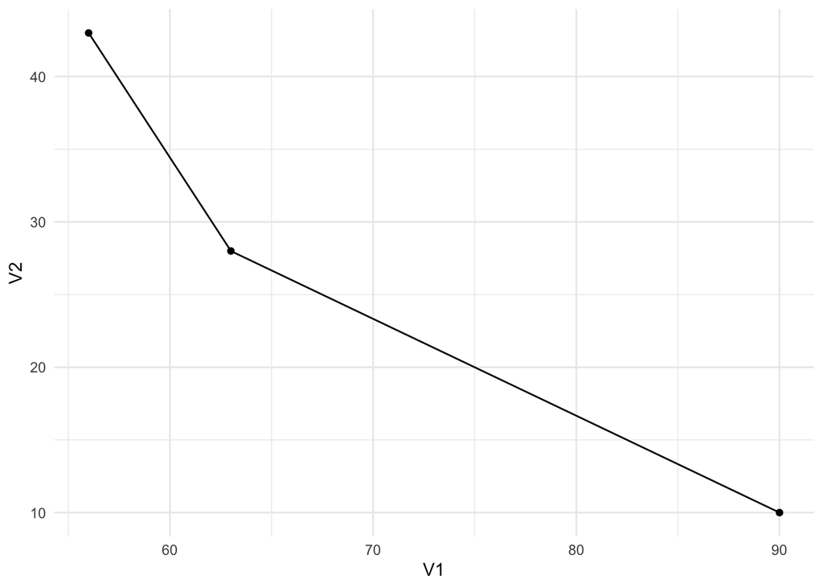

Random Numbers in a Scatter Plot

## References

[The Geometry of Linear Equations](https://ocw.mit.edu/courses/18-06sc-linear-algebra-fall-2011/resources/the-geometry-of-linear-equations/)